# Lecture 2

2025-10-02

# Issues with original plots:

- steps for sizes are poorly distributed, making it unclear what happens in between.
- Plot captions are bad (titles, legend etc).
- Axis labels are bad (overlapping etc)
- Line fitting is not helpful (weird segmented line)

# Load required R libraries

```r
library(tidyr)
library(ggplot2)
library(dplyr)
library(nlstools)
library(purrr)
library(broom)
```

# Read the dataset from CSV and inspect the first few rows

```r
data <- read.csv("measurments.csv")
head(data)
```

```
##   Size Seq     Par Libc
## 1    1   0 4.6e-05    0
## 2    1   0 4.2e-05    0
## 3    1   0 3.7e-05    0
## 4    1   0 4.4e-05    0
## 5    1   0 4.0e-05    0
## 6    1   0 3.9e-05    0
```

# Display a summary of all variables in the dataset

```r
summary(data)
```

```
##       Size             Seq                Par                Libc
##  Min.   :     1   Min.   :0.000000   Min.   :0.000037   Min.   :0.0000000
##  1st Qu.:    90   1st Qu.:0.000005   1st Qu.:0.001484   1st Qu.:0.0000040
##  Median :  3000   Median :0.000220   Median :0.010007   Median :0.0002015
##  Mean   :102423   Mean   :0.012130   Mean   :0.011767   Mean   :0.0116083
##  3rd Qu.: 65000   3rd Qu.:0.006437   3rd Qu.:0.018910   3rd Qu.:0.0059515
##  Max.   :950000   Max.   :0.119757   Max.   :0.052652   Max.   :0.1142500
```

# Convert to long format -> column = on variable (Size, Method, Time), row = one observation

```r
data_long <- pivot_longer(data, cols = c("Seq", "Par", "Libc"),
                          names_to = "Method", values_to = "Time")

head(data_long)
```

```
## # A tibble: 6 × 3
##    Size Method     Time
##   <int> <chr>     <dbl>
## 1     1 Seq    0
## 2     1 Par    0.000046
## 3     1 Libc   0
## 4     1 Seq    0
## 5     1 Par    0.000042
## 6     1 Libc   0
```

# Plot raw data using linear scale

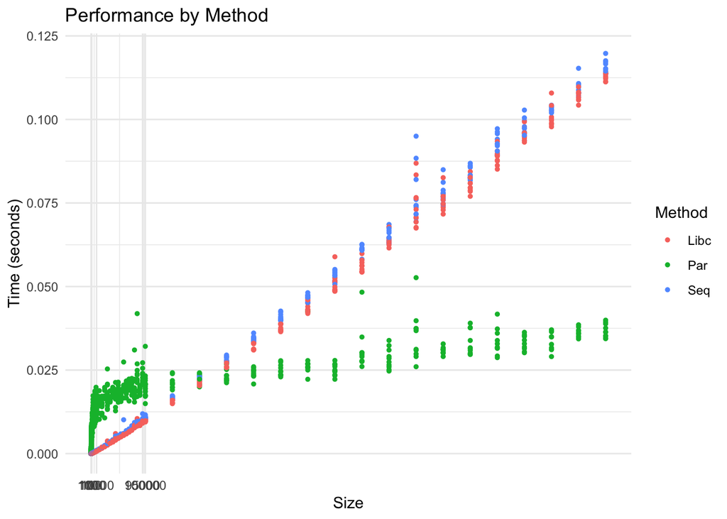

```r
ggplot(data_long, aes(x = Size, y = Time, color = Method)) +
  geom_point(size = 1) +
  labs(
    title = "Performance by Method",
    x = "Size",
    y = "Time (seconds)"
  ) +
  scale_x_continuous(breaks = c(1, 10, 100, 1000, 10000, 95000, 100000, 1000000)) +
  theme_minimal()
```

# Not readable with linear scale, logarithmic needed

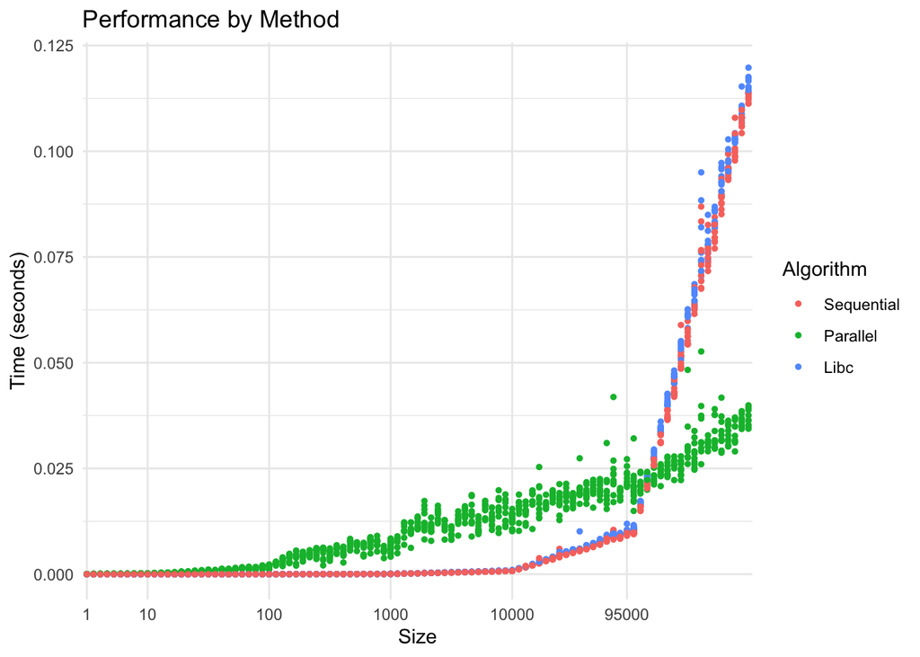

```r
ggplot(data_long, aes(x = factor(Size), y = Time, color = Method)) +
  geom_point(size = 1) +
  scale_color_discrete(
    name = "Algorithm",
    labels = c("Sequential", "Parallel", "Libc")
  ) +
  labs(
    title = "Performance by Method",
    x = "Size",
    y = "Time (seconds)"
  ) +
  scale_x_discrete(breaks = c(1, 10, 100, 1000, 10000, 95000, 100000, 1000000)) +
  theme_minimal()
```

# Sequential and libc implementation we have similar times, for larger data algorithms becomes way slower with bigger sizes, parallel scales nicely :D

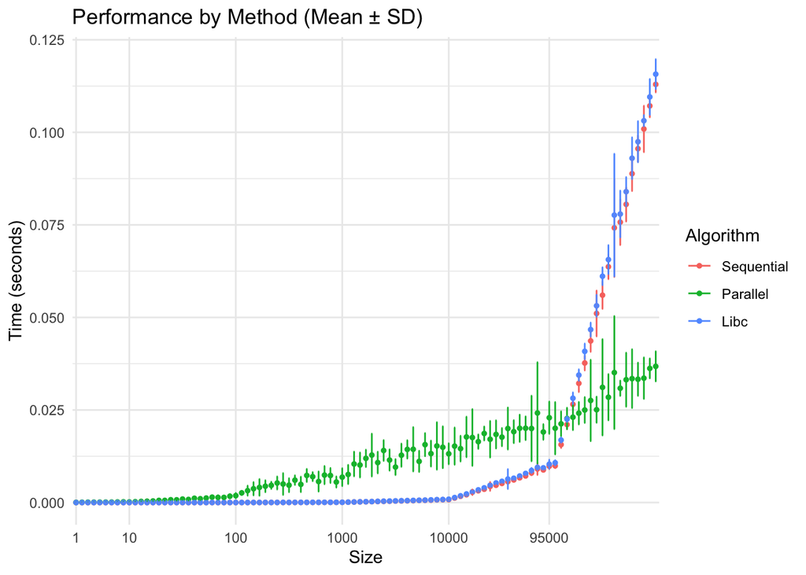

```r
ggplot(data_long, aes(x = factor(Size), y = Time, color = Method)) +
  stat_summary(fun = mean, geom = "point", size = 1) +
  stat_summary(fun.data = mean_sdl, geom = "errorbar", width = 0.2) +
  scale_color_discrete(
    name = "Algorithm",
    labels = c("Sequential", "Parallel", "Libc")
  ) +
  labs(
    title = "Performance by Method (Mean ± SD)",
    x = "Size",
    y = "Time (seconds)"
  ) +

  scale_x_discrete(breaks = c(1, 10, 100, 1000, 10000, 95000, 100000, 1000000)) +
  theme_minimal()
```

# Inspect data and filter the data to void noise points

```r
data_long
```

```
## # A tibble: 3,108 × 3
##     Size Method     Time
##    <int> <chr>     <dbl>
##  1     1 Seq    0
##  2     1 Par    0.000046
##  3     1 Libc   0
##  4     1 Seq    0
##  5     1 Par    0.000042
##  6     1 Libc   0
##  7     1 Seq    0
##  8     1 Par    0.000037
##  9     1 Libc   0
## 10     1 Seq    0
## # ℹ 3,098 more rows
```

```r
colnames(data_long)
```

```
## [1] "Size"   "Method" "Time"
```

```r
data_filtered <- data_long %>%
  filter(Size <= 95000)

data_filtered
```

```
## # A tibble: 2,538 × 3
##     Size Method     Time
##    <int> <chr>     <dbl>
##  1     1 Seq    0
##  2     1 Par    0.000046
##  3     1 Libc   0
##  4     1 Seq    0
##  5     1 Par    0.000042
##  6     1 Libc   0
##  7     1 Seq    0
##  8     1 Par    0.000037
##  9     1 Libc   0
## 10     1 Seq    0
## # ℹ 2,528 more rows
```

# Plot mean ± Standard Deviation (SD) for the filter nada

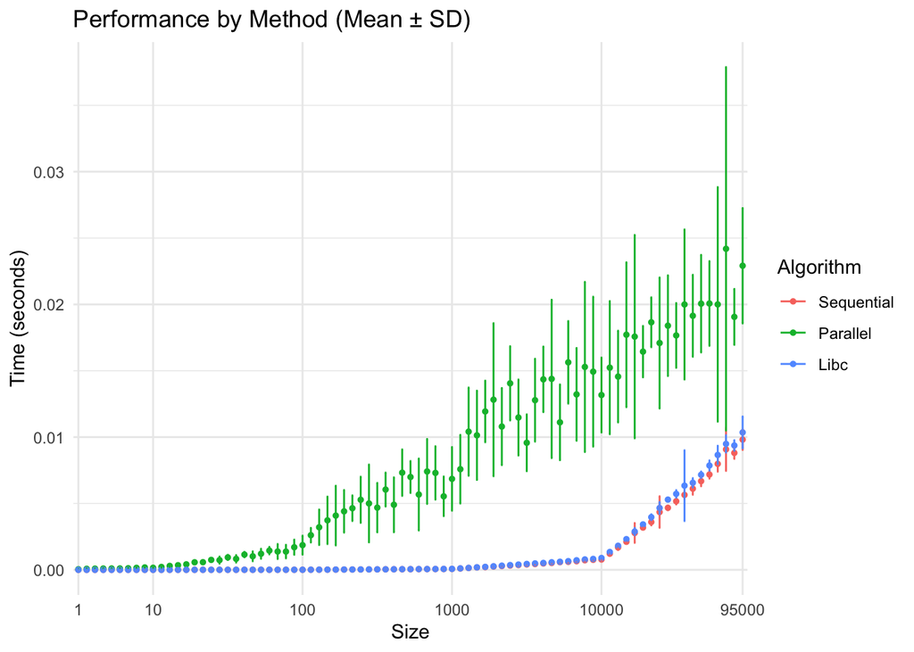

```r
ggplot(data_filtered, aes(x = factor(Size), y = Time, color = Method)) +
  stat_summary(fun = mean, geom = "point", size = 1) +
  stat_summary(fun.data = mean_sdl, geom = "errorbar", width = 0.2) +
  scale_color_discrete(
    name = "Algorithm",
    labels = c("Sequential", "Parallel", "Libc")
  ) +
  labs(
    title = "Performance by Method (Mean ± SD)",
    x = "Size",
    y = "Time (seconds)"
  ) +
  scale_x_discrete(breaks = c(1, 10, 100, 1000, 10000, 95000)) +
  theme_minimal()
```

# Calculate mean and standard deviation of Time for each Size and Method

```r
data_mean <- data_long %>%
  group_by(Size, Method) %>%
  summarise(
    MeanTime = mean(Time),
    SDTime = sd(Time),
    .groups = "drop"
  )
```

# Fit a theoretical model MeanTime = a * Size * log(Size) for each method (complexity ~ n log n)

```r
fits <- data_mean %>%
  group_by(Method) %>%
  nest() %>%
  mutate(
    fit = map(data, ~ nls(MeanTime ~ a * Size * log(Size),
                          data = .x,
                          start = list(a = 1e-7))),
    tidied = map(fit, broom::tidy)
  ) %>%
  unnest(tidied)
```

# Generate fitted (predicted) values from each model for visualization

```r
data_fit <- fits %>%
  rowwise() %>%
  do({
    method_name <- .$Method
    fit_model <- .$fit
    df <- data_mean %>% filter(Method == method_name)
    df$Fitted <- predict(fit_model, newdata = df)
    df
  })
```